# Homework 4

Matt Corsetti

November 7, 2016

## Introduction

I first began tracking my weight on June 26th, 2016 to see how it might fluctuate as I began the first semester of my Ph.D. program at the University of Rochester in Rochester, NY. On June 26th I weigth 176 lbs. As of November 7th, I weighed 159.5 lbs.

### Data Collection

I collected the data by simply weighing myself as soon as I woke up. Measurements were unfortunately not taken every day. Also, the time of the measurement was not consistent. Some measurements were taken as early as 6:00AM while others were taken as late as 11:15AM. No food or liquids were consumed before weighing myself.

Each measurement was entered into the MyFitnessPal app which is provided for free by Under Armour. More information is provided here: http://www.myfitnesspal.com/apps.

## Data Analysis in R

### Reading in the Data

```r
### Libraries

   library(readxl)  # Hadley Wickham's package for reading in excel files
   library(ggplot2) # ggplot2 - nice plots
   library(xtable)  # makes for nice tables


### Directories

   dir.data <- 'C:/Users/Matt/Desktop/My Documents/U of R/BST 494 - Statistical Computing/Data/'


### Read in Weight Data

   w <- read_excel(c(paste0(dir.data, 'Matt Corsetti - Weight Data.xlsx')))
   str(w)
```

```
## Classes 'tbl_df', 'tbl' and 'data.frame':    66 obs. of  2 variables:
##  $ Date  : POSIXct, format: "2016-06-26" "2016-06-27" ...
##  $ Weight: num  176 175 173 173 175 ...
```

### Summary Statistics

```r
   summary(w$Weight)
```

```
##    Min. 1st Qu.  Median    Mean 3rd Qu.    Max.
##   159.5   162.4   168.0   167.0   171.0   176.0
```

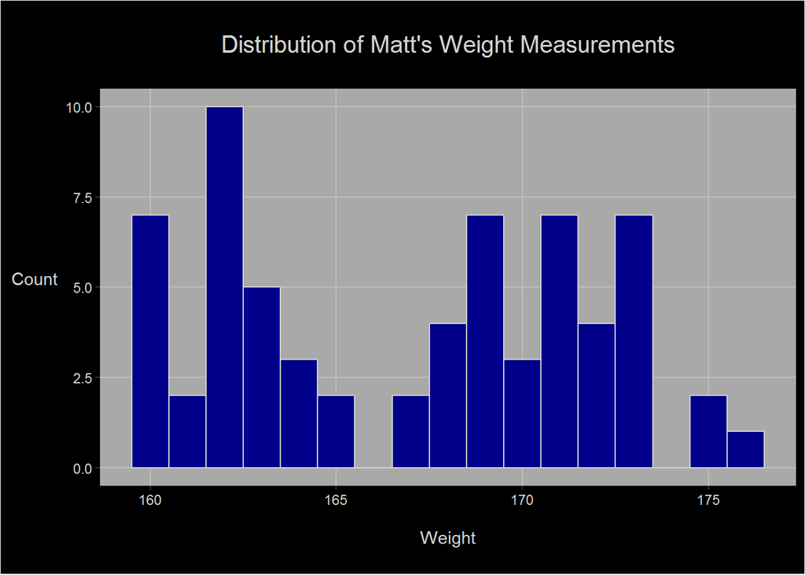

### Weight Measurement Data

[figure not shown]

### Linear Regression Model

Having plotted the data, a linear regression model appears to be a decent model candidate. The steps below show the creation and summary of a linear regression model for the weight data. A plot which overlays the regression model atop the observed data points is also provided.

```r
  lm.w <- lm(Weight ~ Date, data = w)
  cat('Adjusted R-sq:', summary(lm.w)$adj.r.squared)
```

Adjusted R-sq: 0.9456295

```r
  print(xtable(summary(lm.w)), type = 'html')
```

|  | Estimate | Std. Error | t value | Pr(>\|t\|) |
| --- | --- | --- | --- | --- |
| (Intercept) | 2283.2907 | 62.9143 | 36.29 | 0.0000 |
| Date | -0.0000 | 0.0000 | -33.64 | 0.0000 |

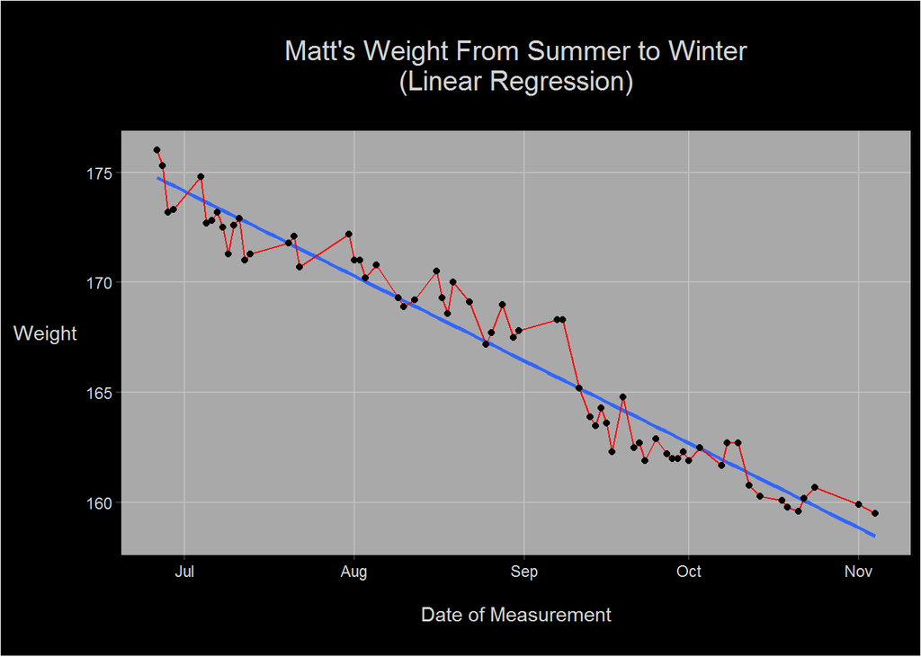

### Loess Curve

Here we provide the Loess Curve to the weight data and plot it atop the observed data points.

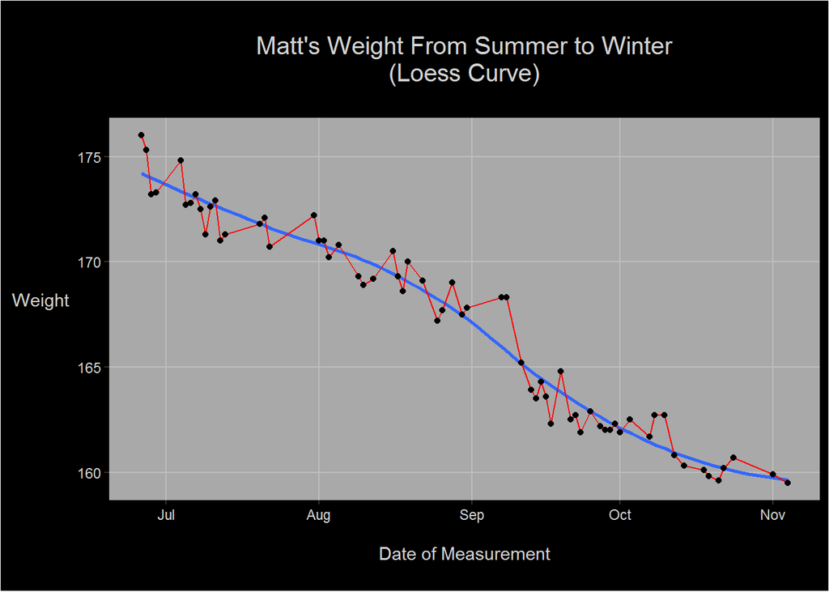